# Distributions for Binomial-like and Poisson-like Counts

## 3.2 Models for Poisson-Like Counts

Among alternatives to the Poisson that allow for departures from the Poisson assumptions of constant rate $\lambda$ and independence between the events that are counted, the negative binomial has been the most widely used, in part because it was for a time the only alternative that was widely implemented. The `gamlss` and other R packages now implement a number of alternatives that can be used with count data.

```r
if(PKGgamlss){
dopoiss <- gamlss(number~1, weights=freq,
                  family=PO, data=machFit, trace=FALSE)
doNBI <- gamlss(number~1, weights=freq,
                family=NBI, data=machFit, trace=FALSE)
doPIG <- gamlss(number~1, weights=freq,
                family=PIG, data=machFit, trace=FALSE)
doZIP <- gamlss(number~1, weights=freq,
                  family=ZIP, data=machFit, trace=FALSE)
## - - - - - - - - - - - - - - - - - - - - - - - - - - -
doZINBI <- gamlss(number~1, weights=freq,
                family=ZINBI, data=machFit, trace=FALSE)
doZIPIG <- gamlss(number~1, weights=freq,
                family=ZIPIG, data=machFit, trace=FALSE, n.cyc=25)
}
```

Modify `family=poisson` as required for `doNBI` (`family=NBI`), `doPIG` (`family=PIG`), and `doZIP` (`family=ZIP`)

```
                         df   AIC dAIC
Poisson inverse gamma     2 767.8  0.0
Negative binomial         2 768.1  0.2
ZI Poisson inverse gamma  3 769.6  1.7
ZI Negative binomial      3 770.1  2.2
ZI Poisson                2 787.3 19.4
Poisson                   1 855.8 88.0
```

The zero-inflated Poisson does do a better job than the Poisson, but is much less satisfactory than a negative binomial or a Poisson inverse gamma model. As there is little to choose between the negative binomial and the Poisson inverse gamma model, the more widely implemented negative binomial fit is likely to be preferred.

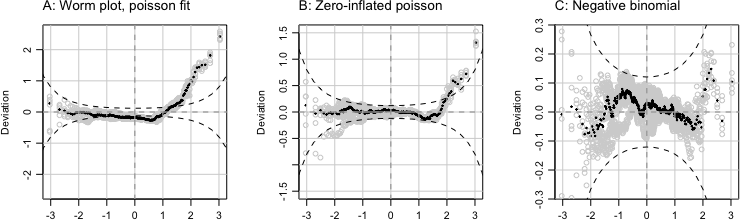

Figure 3.2: Worm plots for the Poisson, for the zero-inflated Poisson, and for the negative binomial.

The following demonstrates the calculation of the fitted frequencies for the negative binomial, Poisson inverse gamma, and zero inflated Poisson fits. The zero inflated Poisson ensures that the estimated number of zeros exactly equals the observed number, but gets the relative numbers of frequencies 1, 2 and 3 badly wrong.

```r
mach <- setNames(numeric(8), nm=c(0:6,8))
mach[names(mach)] <- machinists$ofreq
N <- sum(mach)
if(PKGgamlss){
NBIprob <- dNBI(0:8, mu=fv(doNBI)[1], sigma=fv(doNBI, 'sigma')[1])
PIGprob <- dPIG(0:8, mu=fv(doPIG)[1], sigma=fv(doPIG, 'sigma')[1])
ZIPprob <- dZIP(0:8, mu=fv(doZIP)[1], sigma=fv(doZIP, 'sigma')[1])
estFreqs <- rbind(NegBin=NBIprob, PIG=PIGprob, ZeroInfPoiss=ZIPprob)*N
freqtab <- rbind(Frequencies=c(mach[1:7],0,mach[8]), round(estFreqs,1))
} else
  freqtab<- rbind(
    Frequencies=c(mach[1:7],0,mach[8]),
    NBIprob=c(296.7, 71, 26.4, 11, 4.8, 2.2, 1, 0.5, 0.2),
    PIGprob=c(295.1, 76.9, 23.6, 9.3, 4.2, 2.1, 1.1, 0.6, 0.4),
    ZIPprob=c(296, 62.3, 36.3, 14.1, 4.1, 1, 0.2, 0, 0))
colnames(freqtab) <- 0:8
freqtab
                 0    1    2    3   4   5   6   7   8
Frequencies  296.0 74.0 26.0  8.0 4.0 4.0 1.0 0.0 1.0
NegBin       296.7 71.0 26.4 11.0 4.8 2.2 1.0 0.5 0.2
PIG          295.1 76.9 23.6  9.3 4.2 2.1 1.1 0.6 0.4
ZeroInfPoiss 296.0 62.3 36.3 14.1 4.1 1.0 0.2 0.0 0.0
```

# References

Greenwood, Major, and Hilda M Woods. 1919. *The Incidence of Industrial Accidents Upon Individuals: With Special Reference to Multiple Accidents*. 4. HM Stationery Office, London.

Greenwood, Major, and G Udny Yule. 1920. “An Inquiry into the Nature of Frequency Distributions Representative of Multiple Happenings with Particular Reference to the Occurrence of Multiple Attacks of Disease or of Repeated Accidents.” *Journal of the Royal Statistical Society* 83 (2): 255–79.

McCullagh, P., and J. A. Nelder. 1989. *Generalized Linear Models*. 2nd ed. Chapman; Hall.

Prentice, RL. 1986. “Binary Regression Using an Extended Beta-Binomial Distribution, with Discussion of Correlation Induced by Covariate Measurement Errors.” *Journal of the American Statistical Association* 81 (394): 321–27.

Rigby, Robert A, Mikis D Stasinopoulos, Gillian Z Heller, and Fernanda De Bastiani. 2019. *Distributions for Modeling Location, Scale, and Shape: Using GAMLSS in r*. CRC press.

Rutherford, Ernest, Hans Geiger, and H Bateman. 1910. “LXXVI. The Probability Variations in the Distribution of $\alpha$ Particles.” *The London, Edinburgh, and Dublin Philosophical Magazine and Journal of Science* 20 (118): 698–707.